# Tuto2 : Analyse discriminante

```r
library(tidyverse)
theme_set(theme_classic(base_size=12))
```

## Exercice 1

On considère les données sur les iris de Fisher.

```r
data(iris)
```

1. A l’aide de la fonction **PCA** du package **FactoMineR**, réaliser une ACP en utilisant comme variables actives les 4 variables quantitatives du jeu de données.

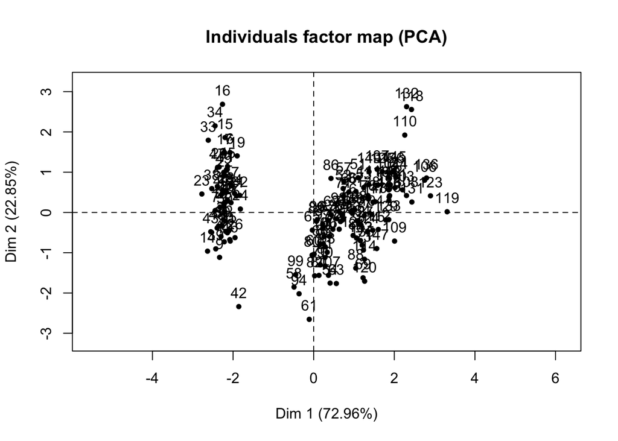

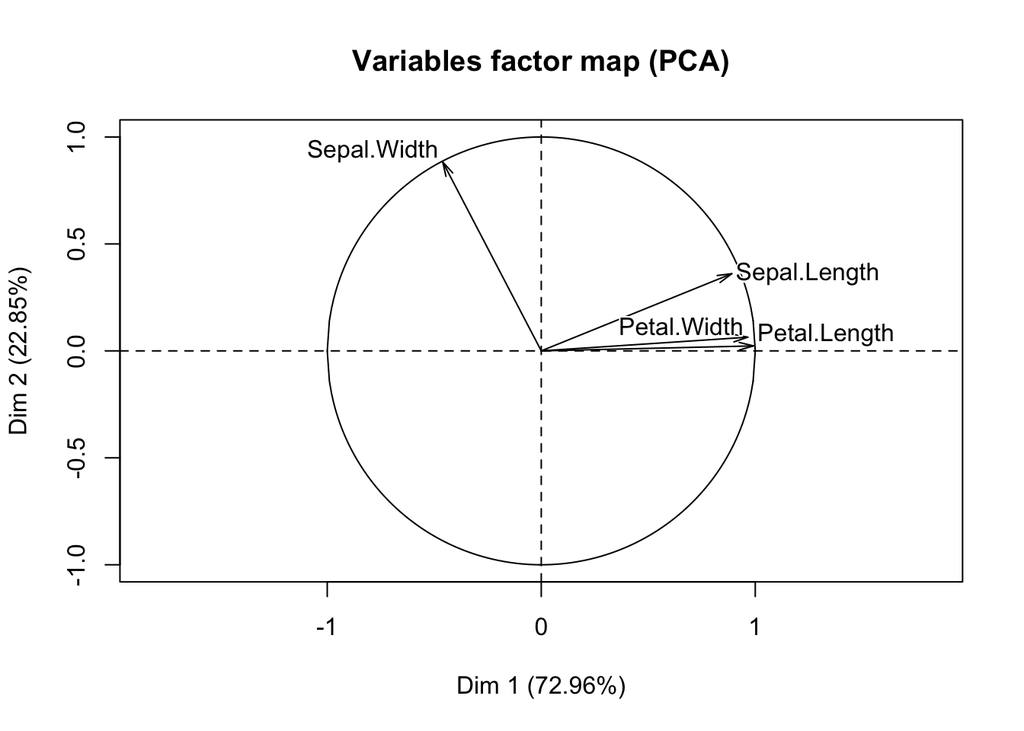

```r
library(FactoMineR)
res.PCA <- PCA(iris[,1:4])
```

2. Représenter le nuage des individus sur les 2 premiers axes de l’ACP en utilisant une couleur différente pour chaque espèce d’iris.

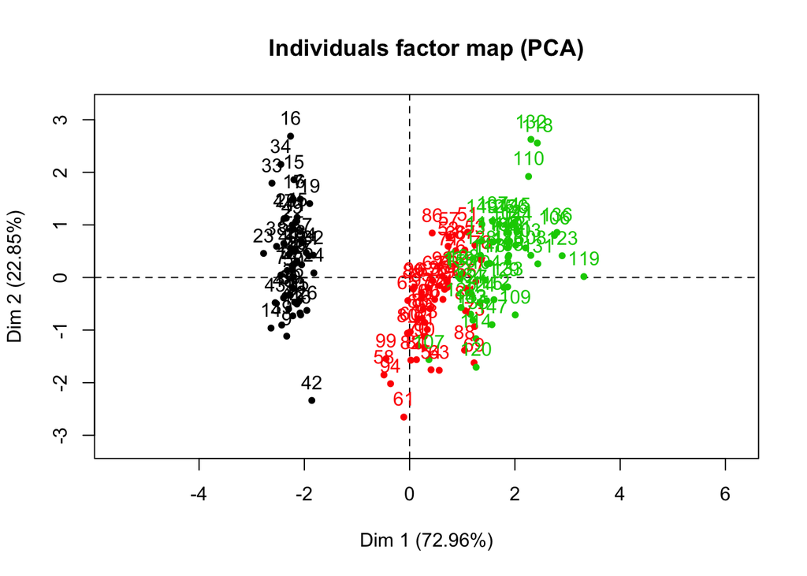

```r
plot(res.PCA,col.ind=as.numeric(iris$Species))
```

3. A l’aide de la fonction **lda** du package **MASS**, effectuer une analyse discriminante linéaire permettant d’expliquer l’espèce par les 4 autres variables explicatives.

```r
library(MASS)
mod.lda <- lda(Species~.,data=iris)
```

4. Représenter le nuage des individus sur les deux premiers axes de l’analyse discriminante linéaire (en utilisant une couleur différente pour chaque espèce d’iris).

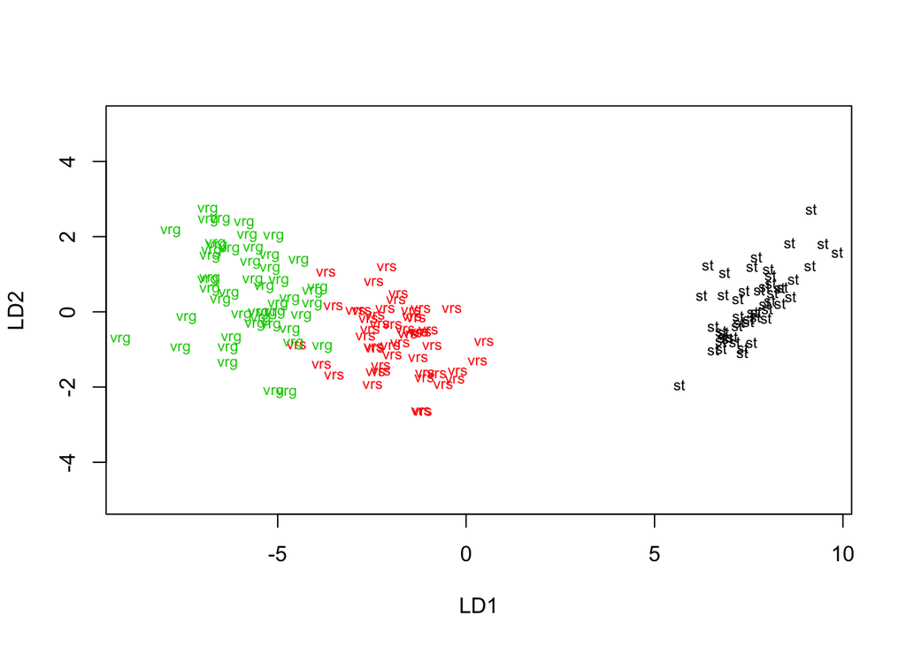

```r
plot(mod.lda,abbrev=2,col=as.numeric(iris$Species))
```

5. Rappeler comment sont obtenues les coordonnées des individus sur chaque axe. En déduire une interprétation de la position des individus.

Compte tenu de la sortie

```r
mod.lda$scaling
```

```
##                     LD1         LD2
## Sepal.Length  0.8293776  0.02410215
## Sepal.Width   1.5344731  2.16452123
## Petal.Length -2.2012117 -0.93192121
## Petal.Width  -2.8104603  2.83918785
```

on déduit que l’axe 1 oppose les individus ayant des grosses Sépales (à droite) à ceux ayant des grosses pétales (à gauche).

6. Comparer les représentations des questions 2 et 4.

Pour le problème considéré, la représentation de la question 4 parait plus pertinente. C’est normal dans la mesure où elle prend en compte les groupes des individus pour construire les axes (contrairement à l’ACP).

7. Expliquer les sorties

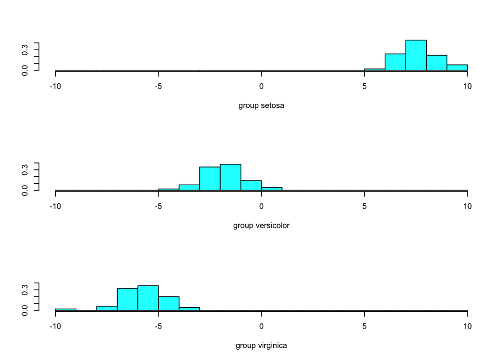

```r
score <- predict(mod.lda)$x
ldahist(score[,1],iris[,5])
```

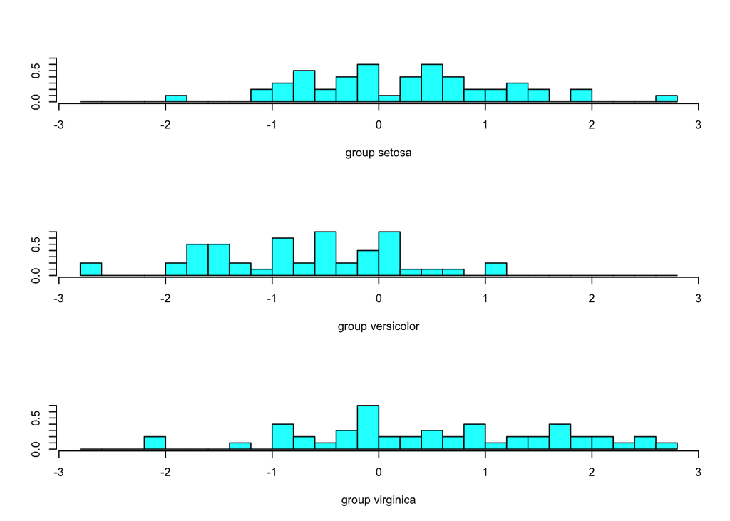

```r
ldahist(score[,2],iris[,5])
```

Score contient les coordonnées des projections des individus sur les axes de l’analyse discriminante. On obtient ensuite les histogrammes correspondants aux distributions des coordonnées pour chaque groupe. On visualise clairement que le premier axe est très discriminant. C’est renforcé par la sortie :

```markdown
Proportion of trace:
   LD1    LD2
0.9912 0.0088
```

8. Exécuter et analyser les sorties de la commande

```r
mod.lda2 <- lda(Species~.,data=iris,CV=TRUE)
```

On obtient ici les groupes et les probabilités a posteriori calculés par validation croisée LOO :

```r
head(mod.lda2$class)
```

```
## [1] setosa setosa setosa setosa setosa setosa
## Levels: setosa versicolor virginica
```

```r
head(mod.lda2$posterior)
```

```
##   setosa   versicolor    virginica
## 1      1 5.087494e-22 4.385241e-42
## 2      1 9.588256e-18 8.888069e-37
## 3      1 1.983745e-19 8.606982e-39
## 4      1 1.505573e-16 5.101765e-35
## 5      1 2.075670e-22 1.739832e-42
## 6      1 5.332271e-21 8.674906e-40
```

9. Comparer, en terme d’erreur de prévision, les performances de LDA et QDA.

```r
mod.qda <- qda(Species~.,data=iris,CV=TRUE)
mean(mod.lda2$class!=iris$Species)
```

```
## [1] 0.02
```

```r
mean(mod.qda$class!=iris$Species)
```

```
## [1] 0.02666667
```

On peut retrouver ces résultats avec une syntaxe **dplyr** :

```r
prev <- data.frame(LDA=mod.lda2$class,QDA=mod.qda$class,obs=iris$Species)
prev %>% summarise_at(1:2,~mean((.!=obs)))
```

| LDA | QDA |
| --- | --- |
| 0.02 | 0.02666667 |

## Exercice 2

1. On considère les jeux de données **Vowel** (training et test) qui se trouvent à cet [url](https://statweb.stanford.edu/~hastie/ElemStatLearn/). On peut les importer avec

```r
dapp <- read_csv("https://web.stanford.edu/~hastie/ElemStatLearn/datasets/vowel.train")[,-1]
dtest <- read_csv("https://web.stanford.edu/~hastie/ElemStatLearn/datasets/vowel.test")[,-1]
```

Expliquer le problème.

2. Effectuer une analyse discriminante linéaire (uniquement avec les données d’apprentissage) et visualiser les individus sur les 2 premiers axes de l’analyse discriminante. On pourra utiliser **predict**.

```r
mod <- lda(y~.,data=dapp)
```

Il faut ici récupérer les coordonnées des individus sur chaque axe :

```r
prev <- as.data.frame(predict(mod)$x) %>%
  mutate(y=as.factor(dapp$y))
```

On peut ainsi obtenir le graphe demandé.

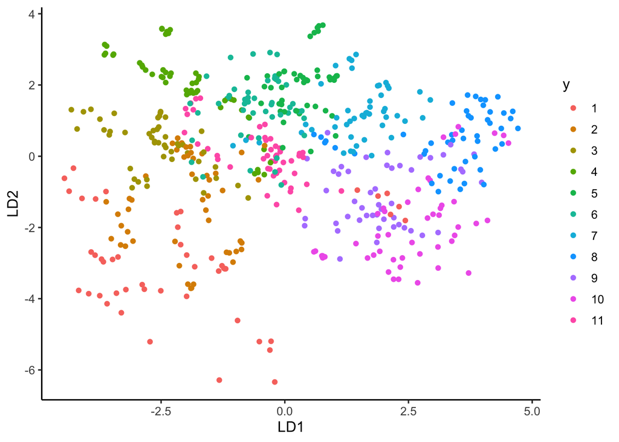

```r
ggplot(prev)+aes(x=LD1,y=LD2,color=y)+geom_point()
```

3. La fonction suivante permet de choisir les axes à visualiser, ainsi que les centres de gravité projetés des groupes.

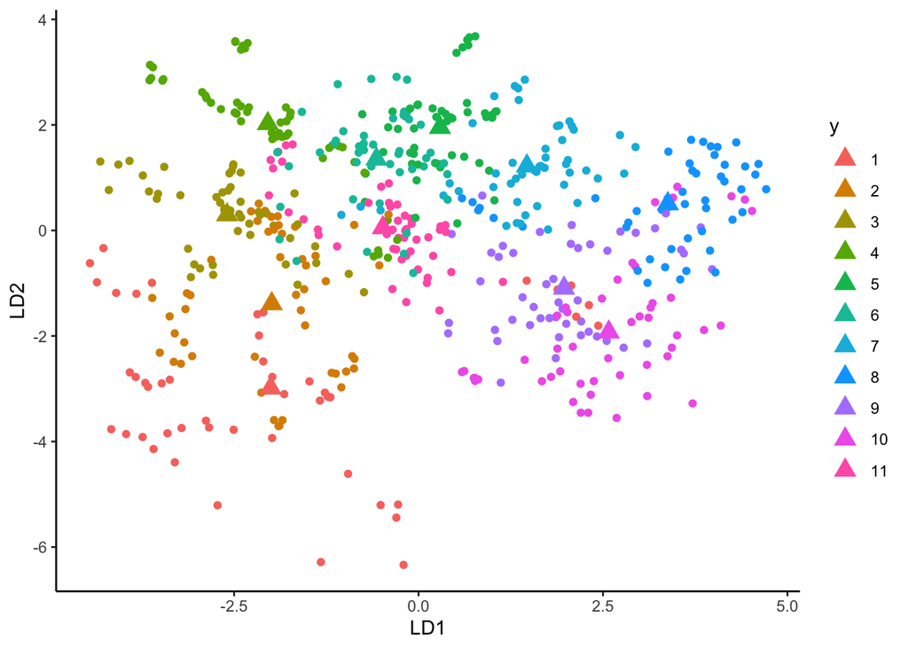

```r
cdg <- prev %>% group_by(y) %>% summarise_all(mean)
repres_axes <- function(prev,cdg,axe1=1,axe2=2){
  nom1 <- paste("LD",as.character(axe1),sep="")
  nom2 <- paste("LD",as.character(axe2),sep="")
  ggplot(prev)+aes_string(x=as.name(nom1),y=as.name(nom2))+geom_point(aes(color=y))+geom_point(data=cdg,aes(color=y),shape=17,size=4)+theme_classic()
}
repres_axes(prev,cdg,1,2)
```

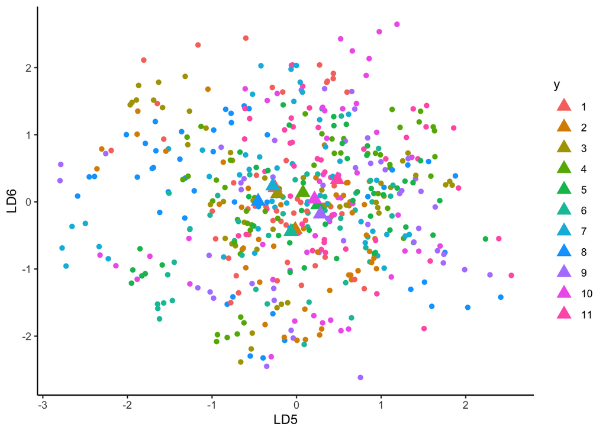

```r
repres_axes(prev,cdg,5,6)
```

Etudier la pertinence des axes.

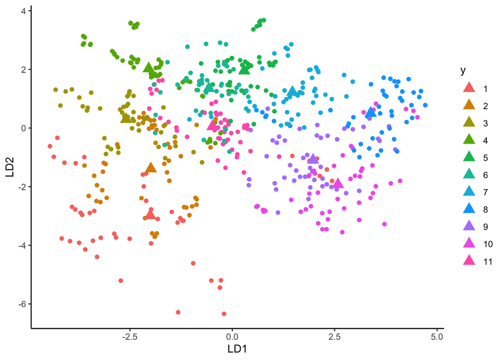

```r
repres_axes(prev,cdg,1,2)
```

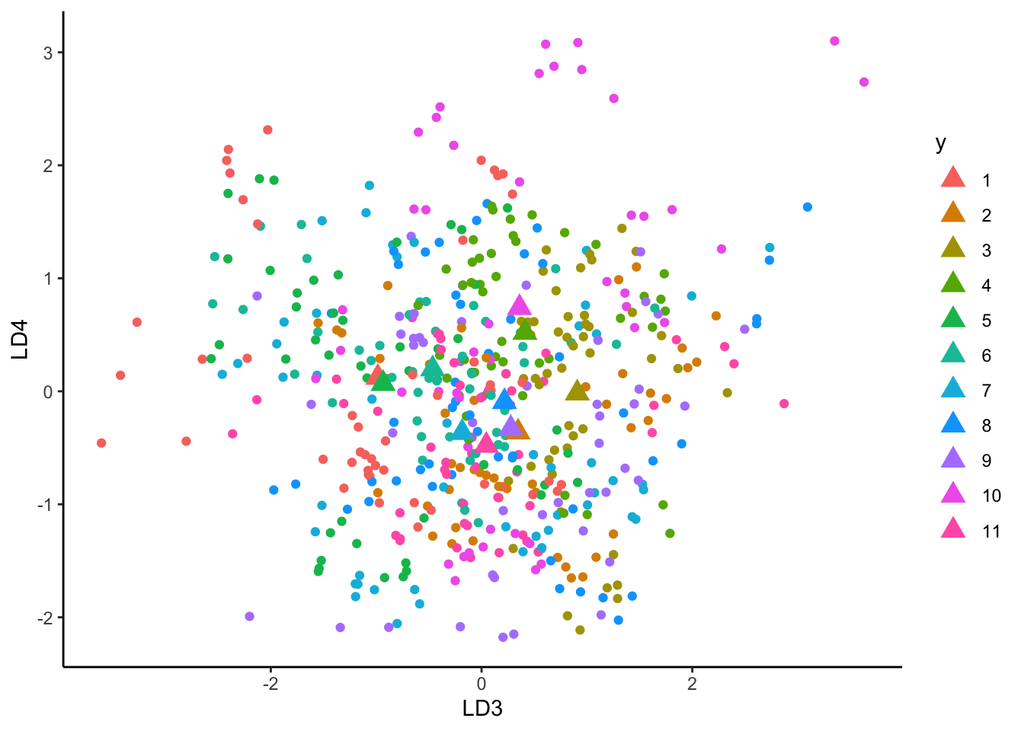

```r
repres_axes(prev,cdg,3,4)
```

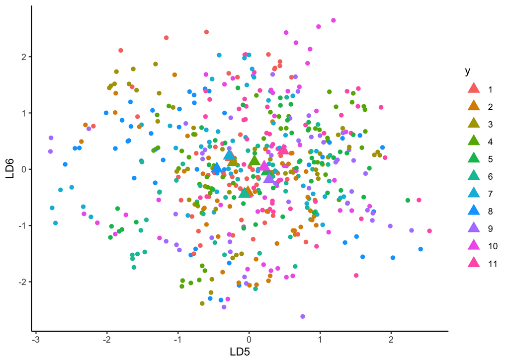

```r
repres_axes(prev,cdg,5,6)
```

Les groupes sont mieux séparés sur les premiers axes de l’analyse, ce qui est logique. On peut le vérifier en étudiant la sortie **Proportion of trace** de la fonction **lda**.

```markdown
Proportion of trace:
   LD1    LD2    LD3    LD4    LD5    LD6    LD7    LD8
0.5617 0.3518 0.0445 0.0191 0.0107 0.0083 0.0026 0.0011
   LD9   LD10
0.0001 0.0001
```

4. Représenter les individus sur le premier plan factoriel de l’ACP, on utilisera une couleur différente pour chaque groupe. On pourra utiliser le package **FactoMineR**.

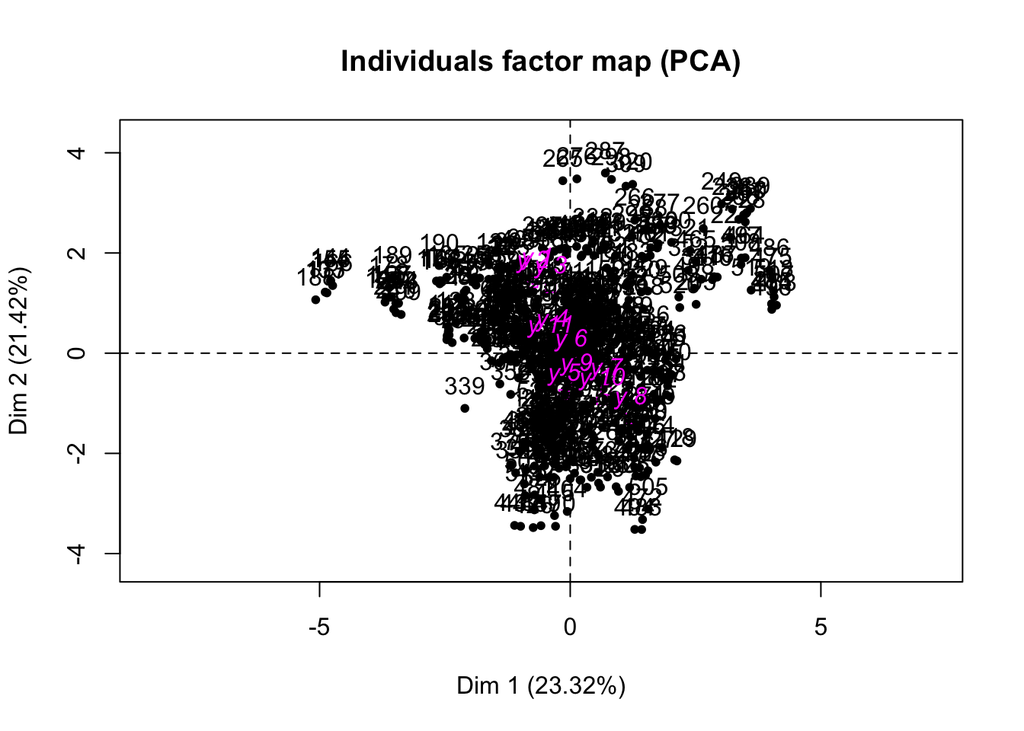

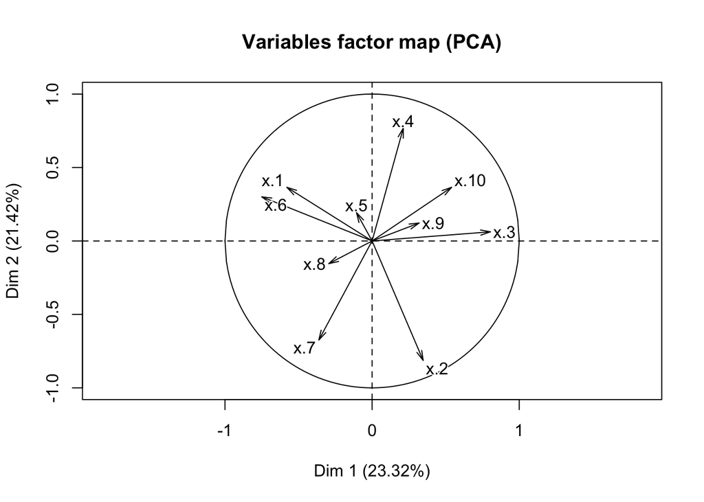

```r
acp <- PCA(dapp,quali.sup=1)
```

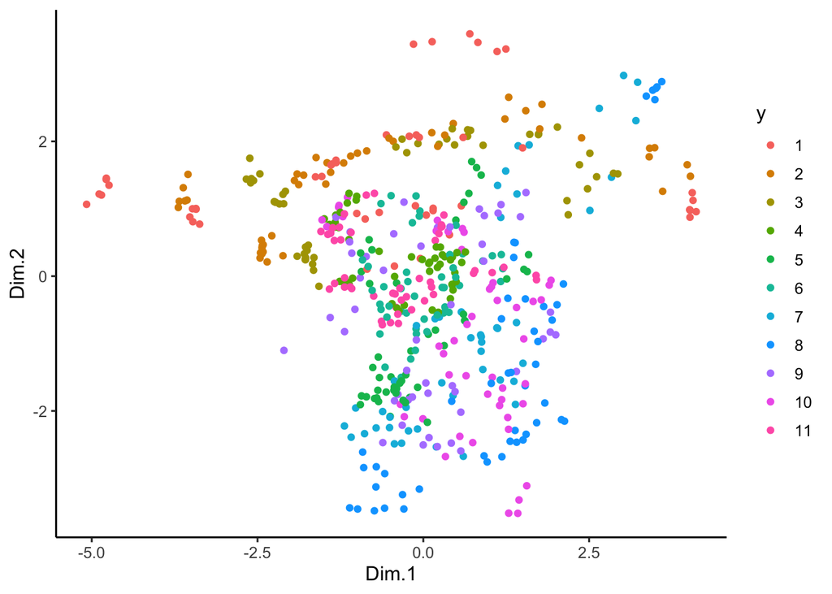

```r
coord <- as.data.frame(acp$ind$coord)
coord$y <- as.factor(dapp$y)
ggplot(coord)+aes(x=Dim.1,y=Dim.2,color=y)+geom_point()
```

5. Comparer cette projection avec celle obtenue par l’analyse discriminante linéaire.

La projection de l’ACP semble moins séparer les groupes que l’analyse discriminante. Ca parait logique.

6. Evaluer la performance de lda sur les données test. Comparer avec l’analyse discriminante quadratique.

```r
mod.qda <- qda(y~.,data=dapp)
preva <- data.frame(LDA=predict(mod,newdata=dtest)$class,QDA=predict(mod.qda,newdata=dtest)$class,y=dtest$y)
preva %>% summarise_at(1:2,~mean(y!=.))
```

| LDA | QDA |
| --- | --- |
| 0.5562771 | 0.5281385 |

7. Expliquer comment on peut faire de la prévision en réduisant la dimension de l’espace des $X$.

On utilise les projections sur les $k$ premiers axes de l’analyse discriminante.

8. Proposer une méthode permettant de choisir le meilleur nombre d’axes.

On estime la probabilité d’erreur en fonction de la dimension de l’espace sur lequel on projette.

```r
prev_lab <- predict(mod,newdata=dtest)$class
mean(prev_lab!=dtest$y)
```

```
## [1] 0.5562771
```

```r
PREV <- matrix(0,ncol=10,nrow=nrow(dtest)) %>% as.data.frame()
for (i in 1:10){
  PREV[,i] <- predict(mod,newdata=dtest,dimen=i)$class
}
names(PREV) <- paste("P",1:10,sep="")

PREV %>% mutate(y=dtest$y) %>% summarise_at(1:10,~mean(y!=.))
```

| P1 | P2 | P3 | P4 | P5 | P6 | P7 | P8 | P9 | P10 |
| --- | --- | --- | --- | --- | --- | --- | --- | --- | --- |
| 0.6991342 | 0.491342 | 0.495671 | 0.5108225 | 0.5151515 | 0.5541126 | 0.5541126 | 0.5562771 | 0.5519481 | 0.5562771 |

On choisira deux axes.

## Exercice 3

On considère le jeu de données **phoneme** téléchargeable à l’url https://github.com/cran/ElemStatLearn/blob/master/data/phoneme.RData.

```r
load("phoneme.RData")
data(phoneme)
donnees <- phoneme[,-258]
```

1. Expliquer le problème et représenter pour chaque groupe la courbe moyenne.

Il s’agit d’expiquer un son parmi 5 à partir de courbes discrétisées en 256 points.

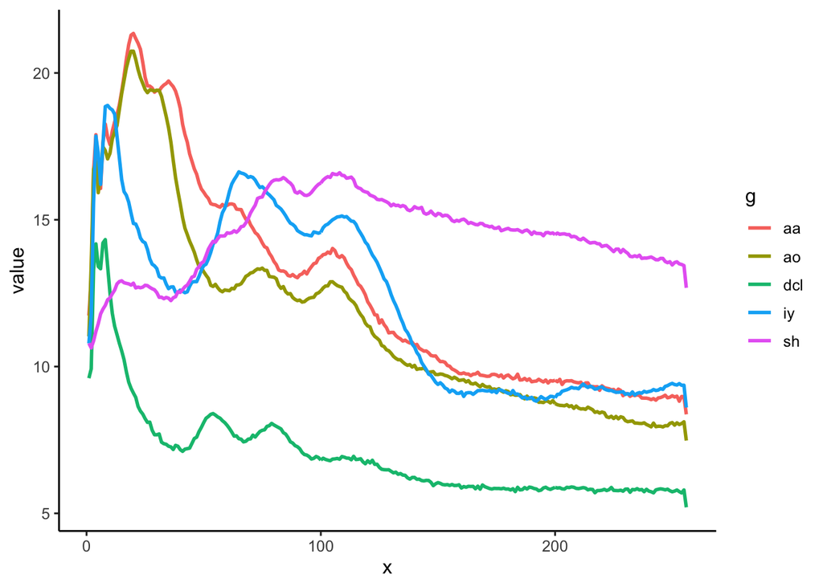

```r
moy_groupe <- donnees %>% group_by(g) %>% summarise_all(mean)
names(moy_groupe)[2:257] <- as.character(1:256)
moy_plot <- moy_groupe %>% gather(key=x,value=value,-g)
ggplot(moy_plot)+aes(x=as.numeric(x),y=value,color=g)+geom_line(size=1)+xlab("x")
```

2. Séparer les données en un échantillon d’apprentissage de taille 3000 et un échantillon test de taille 1509.

```r
set.seed(1234)
perm <- sample(nrow(donnees))
dapp <- donnees[perm[1:3000],]
dtest <- phoneme[perm[3001:4509],]
```

3. Effectuer une analyse discriminante linéaire et une analyse discriminante quadratique sur les données d’apprentissage uniquement. Evaluer les performances de ces deux approches sur les données test.

```r
library(MASS)
mod <- lda(g~.,data=dapp)
mod1 <- qda(g~.,data=dapp)
prev <- data.frame(LDA=predict(mod,newdata=dtest)$class,QDA=predict(mod1,newdata=dtest)$class,obs=dtest$g)
prev %>% summarise_at(1:2,~mean(obs!=.))
```

| LDA | QDA |
| --- | --- |
| 0.0702452 | 0.175613 |

4. Quel peuvent être les intérêts d’effectuer une analyse disciminante régularisée dans ce contexte ? Effectuer une telle analyse à l’aide de la fonction *rda* du package **klaR**.

Le nombre de variables est élevé. De plus, les données étant fonctionnelles, on a de la corrélation entre les $X$.

```r
library(klaR)
mod2 <- rda(g~.,data=dapp)
prev2 <- predict(mod2,newdata=dtest)$class
prev <- prev %>% mutate(RDA=prev2)
prev %>% summarise_at(vars(-3),~mean(obs!=.))
```

| LDA | QDA | RDA |
| --- | --- | --- |
| 0.0702452 | 0.175613 | 0.06229291 |

5. Sélectionner les paramètres de régularisation à l’aide du package **caret**. Comparer le nouveau modèle aux précédents.

```r
library(caret)
gamma <- seq(0,1,by=0.25)
lambda <- seq(0,1,by=0.25)
grille <- expand.grid(lambda=lambda,gamma=gamma)
ctrl1 <- trainControl(method="cv",number=5)
library(doMC)
registerDoMC(4)
system.time(mod3 <- train(g~.,data=donnees,method="rda",trControl=ctrl1,tuneGrid=grille))
```

```
##    user  system elapsed
## 414.766   6.777 109.799
```

```r
getTrainPerf(mod3)
```

| TrainAccuracy | TrainKappa | method |
| --- | --- | --- |
| 0.9279235 | 0.9090368 | rda |

```r
prev3 <- predict(mod3,newdata=dtest)
prev <- prev %>% mutate(RDA2=prev3)
prev %>% summarise_at(vars(-3),~mean(obs!=.))
```

| LDA | QDA | RDA | RDA2 |
| --- | --- | --- | --- |
| 0.0702452 | 0.175613 | 0.06229291 | 0.0629556 |

```r
registerDoMC(1)
```